# Assignment 3.1

## Problem 3.3.

The 49 students in a class at the University of Florida made blinded evaluations of pairs of cola drinks. For the 49 comparisons of Coke and Pepsi, Coke was preferred 29 times. In the population that this sample represents, is this strong evidence that a majority prefers Coke? Use a simulation of a sampling distribution to answer.

`Your answer goes here`

[figure not shown]

```
The p-value is: 0.12
```

```python
import numpy as np
import matplotlib.pyplot as plt

n = 49  # Sample size
observed_coke_preferences = 29  # Number of times Coke was preferred

# Simulate the sampling distribution under the null hypothesis (50% preference)
num_simulations = 10000
simulated_coke_preferences = []
for _ in range(num_simulations):
    # Simulate a sample from a binomial distribution with probability 0.5
    sample = np.random.binomial(n, 0.5, 1)
    simulated_coke_preferences.append(sample[0])

# Calculate the proportion of simulations where the number of Coke preferences
# is greater than or equal to the observed number of Coke preferences
p_value = np.mean(np.array(simulated_coke_preferences) >= observed_coke_preferences)

# Plotting the histogram of simulated proportions
plt.hist(simulated_coke_preferences, bins=30)
plt.xlabel("Number of Coke Preferences")
plt.ylabel("Frequency")
plt.title("Distribution of Simulated Number of Coke Preferences")
plt.axvline(observed_coke_preferences, color='red', linestyle='dashed', linewidth=2,
            label=f"Observed Number of Coke Preferences ({observed_coke_preferences})")
plt.legend()
plt.show()

print(f"The p-value is: {p_value:.2f}")
```

The p-value represents the probability of observing a sample proportion as extreme or more extreme than the one observed, assuming that the null hypothesis (50% preference) is true. A smaller p-value indicates stronger evidence against the null hypothesis.

# Conclusion:

Based on the simulation and the p-value, we can conclude that there is some evidence that a majority prefers Coke. The p-value is not extremely small, but the observed number of Coke preferences is somewhat higher than what would be expected under a 50% preference assumption. However, we cannot say with high confidence that a majority prefers Coke without further investigation.

## Problem 3.5.

The example in Section 3.1.4 simulated sampling distributions of the sample mean to determine how precise $\bar{Y}$ for $n=25$ may estimate a population mean $\mu.$

a) Find the theoretical standard error of $\bar{Y}$ for the scenario values of $\sigma = 5$ and 8. How do they compare to the standard deviations of the 100,000 sample means in the simulations?

`Your answer goes here`

```python
# Theoretical standard error of Ȳ for σ = 5 and n = 25
sigma_1 = 5
n = 25
standard_error_1 = sigma_1 / (n ** 0.5)
print(f"The theoretical standard error of Ȳ for σ = 5 is: {standard_error_1:.2f}")

# Theoretical standard error of Ȳ for σ = 8 and n = 25
sigma_2 = 8
standard_error_2 = sigma_2 / (n ** 0.5)
print(f"The theoretical standard error of Ȳ for σ = 8 is: {standard_error_2:.2f}")
```

```
The theoretical standard error of Ȳ for σ = 5 is: 1.00
The theoretical standard error of Ȳ for σ = 8 is: 1.60
```

The standard deviation of the 100,000 sample means should be very close to the theoretical standard error. The simulation results should confirm that the standard deviation of the sample means is a good estimate of the theoretical standard error. We would expect the standard deviation of the sample means from the simulation to be very close to the theoretical standard error calculated above.

b) In the first scenario, we chose $\sigma = 5$ under the belief that if $\mu = 20$, about 2/3 of the sample values would fall between `$`15 and `$`25. For the gamma distribution with $(\mu, \sigma) = (20,5),$ show that the actual probability between 15 and 25 is 0.688.

`Your answer goes here`

```python
import scipy.stats as stats

mu = 20
sigma = 5
probability = stats.norm.cdf(25, loc=mu, scale=sigma) - stats.norm.cdf(15, loc=mu, scale=sigma)

print(f"The probability between 15 and 25 is: {probability:.3f}")
```

```
The probability between 15 and 25 is: 0.683
```

## Problem 3.8.

Construct the sampling distribution of the sample proportion of heads, for flipping a balanced coin (a) once; (b) twice; (c) three times; (d) four times. Describe how the shape changes as the number of flips $n$ increases. What would happen if $n$ kept growing? Why?

`Your answer goes here`

```
Sampling distribution for 1 flip: Counter({0.0: 1, 1.0: 1})
```

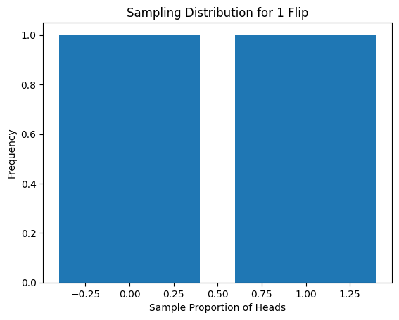

```
Sampling distribution for 2 flips: Counter({0.5: 2, 0.0: 1, 1.0: 1})
```

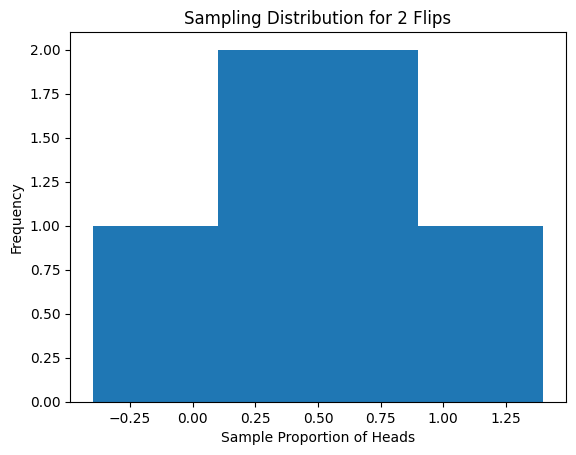

```
Sampling distribution for 3 flips: Counter({0.33: 3, 0.67: 3, 0.0: 1, 1.0: 1})
```

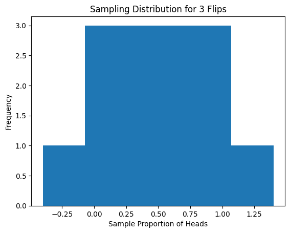

```
Sampling distribution for 4 flips: Counter({0.5: 6, 0.25: 4, 0.75: 4, 0.0: 1, 1.0: 1})
```

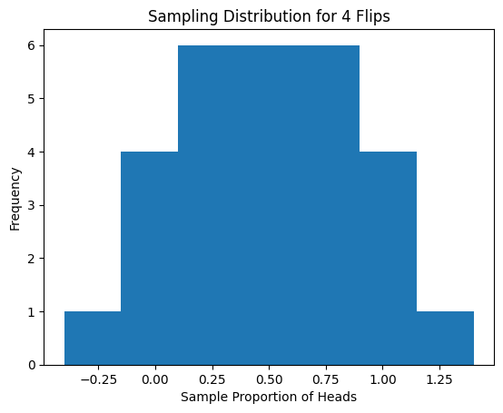

```python
import numpy as np
import matplotlib.pyplot as plt
from collections import Counter

def get_sample_distribution(n_flips):
    all_outcomes = []
    for i in range(2**n_flips):
        binary_representation = bin(i)[2:].zfill(n_flips)
        heads_count = binary_representation.count('1')
        sample_proportion =  round(heads_count / n_flips, 2)
        all_outcomes.append(sample_proportion)
    return Counter(all_outcomes)

# (a) Once
sample_distribution_1 = get_sample_distribution(1)
print("Sampling distribution for 1 flip:", sample_distribution_1)
plt.bar(sample_distribution_1.keys(), sample_distribution_1.values())
plt.title("Sampling Distribution for 1 Flip")
plt.xlabel("Sample Proportion of Heads")
plt.ylabel("Frequency")
plt.show()

# (b) Twice
sample_distribution_2 = get_sample_distribution(2)
print("Sampling distribution for 2 flips:", sample_distribution_2)
plt.bar(sample_distribution_2.keys(), sample_distribution_2.values())
plt.title("Sampling Distribution for 2 Flips")
plt.xlabel("Sample Proportion of Heads")
plt.ylabel("Frequency")
plt.show()

# (c) Three times
sample_distribution_3 = get_sample_distribution(3)
print("Sampling distribution for 3 flips:", sample_distribution_3)
plt.bar(sample_distribution_3.keys(), sample_distribution_3.values())
plt.title("Sampling Distribution for 3 Flips")
plt.xlabel("Sample Proportion of Heads")
plt.ylabel("Frequency")
plt.show()

# (d) Four times
sample_distribution_4 = get_sample_distribution(4)
print("Sampling distribution for 4 flips:", sample_distribution_4)
plt.bar(sample_distribution_4.keys(), sample_distribution_4.values())
plt.title("Sampling Distribution for 4 Flips")
plt.xlabel("Sample Proportion of Heads")
plt.ylabel("Frequency")
plt.show()
```

# Description of shape changes:

As n increases, the sampling distribution becomes more symmetric and bell-shaped. This is due to the Central Limit Theorem, which states that the sampling distribution of the sample mean (or proportion) approaches a normal distribution as the sample size increases.

# What would happen if n kept growing?

If n kept growing, the sampling distribution would become even more closely approximated by a normal distribution with a mean of 0.5 (since the coin is balanced) and a standard deviation that decreases as n increases. This means that the sample proportions would be clustered more tightly around 0.5 as the number of flips increases.

# Why?

This happens because with a larger sample size, the effects of random fluctuations in individual flips become less significant, and the overall proportion of heads tends to converge towards the true population proportion (0.5 in this case). The Central Limit Theorem mathematically explains this phenomenon.

## Problem 3.13.

Simulate random sampling from a uniform population distribution with several $n$ values to illustrate the Central Limit Theorem.

`Your answer goes here`

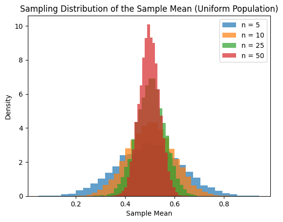

```python
import numpy as np
import matplotlib.pyplot as plt

def simulate_sampling_distribution(population_size, sample_size, num_simulations):
    population = np.random.uniform(0, 1, population_size)  # Uniform population
    sample_means = []

    for _ in range(num_simulations):
        sample = np.random.choice(population, sample_size, replace=False)
        sample_means.append(np.mean(sample))

    return sample_means

# Parameters for the simulation
population_size = 10000
num_simulations = 10000
sample_sizes = [5, 10, 25, 50]

# Simulate and plot the sampling distribution for different sample sizes
for sample_size in sample_sizes:
    sample_means = simulate_sampling_distribution(population_size, sample_size, num_simulations)

    plt.hist(sample_means, bins=30, density=True, alpha=0.7, label=f'n = {sample_size}')

plt.xlabel('Sample Mean')
plt.ylabel('Density')
plt.title('Sampling Distribution of the Sample Mean (Uniform Population)')
plt.legend()
plt.show()
```

## Problem 3.14.

On each bet in a sequence of bets, you win 1 dollar with probability 0.50 and lose 1 dollar (i.e., win negative 1 dollar) with probability 0.50. Let $Y$ denote the total of your winnings and losings after 100 bets. Giving your reasoning, state the approximate distribution of $Y.$

`Your answer goes here`

The approximate distribution of Y is a normal distribution with mean 0 and standard deviation sqrt(100).

# Reasoning:

Each bet is an independent event with a probability of `0.5 of winning $1 and 0.5 of losing $1.` The expected value of each bet is `0.5 * $1 + 0.5 * (-$1) = $0.` The variance of each bet is `0.5 * ($1 - $0)^2 + 0.5 * (-$1 - $0)^2 = $1.` The total winnings and losings after 100 bets is the sum of 100 independent bets. By the Central Limit Theorem, the sum of a large number of independent random variables with finite mean and variance tends towards a normal distribution. Therefore, the approximate distribution of Y is a normal distribution with mean `100 * $0 = $0 and variance 100 * $1 = $100.` `The standard deviation of Y is sqrt(100) = $10.`

In conclusion, the approximate distribution of Y is a normal distribution with mean`$0 and standard deviation $10.`

## Problem 3.15.

According to a General Social Survey, in the United States the population distribution of $Y$ = number of good friends (not including family members) has a mean of about 5.5 and a standard deviation of about 3.9.

a) Is it plausible that this population distribution is normal? Explain.

`Your answer here`

It's not plausible that the population distribution of the number of good friends is normally distributed.

# Reasoning:

1. The number of good friends is a discrete variable, and it must be a non-negative integer.
2. A normal distribution is continuous and can take on any real number.
3. The number of good friends cannot be negative, which is a limitation of the normal distribution.
4. The distribution is likely skewed to the right, with a few people having a very large number of good friends, while most people have a relatively small number.

In conclusion, the normal distribution is not a plausible model for the population distribution of the number of good friends. A better model might be a Poisson distribution or a discrete distribution with a skewed distribution.

b) If a new survey takes a simple random sample of 1000 people, describe the sampling distribution of $\bar{Y}$ by giving its shape and approximate mean and standard error.

`Your answer here`

```python
# Given information
population_mean = 5.5
population_std_dev = 3.9
sample_size = 1000
# Approximate mean of the sampling distribution:
sample_mean = population_mean
print(f"Approximate mean of the sampling distribution: {sample_mean:.2f}")

# Approximate standard error of the sampling distribution:
standard_error = population_std_dev / (sample_size**0.5)
print(f"Approximate standard error of the sampling distribution: {standard_error:.2f}")
```

```
Approximate mean of the sampling distribution: 5.50
Approximate standard error of the sampling distribution: 0.12
```